# Minería de Datos

Clase 13: Regresión Lineal, Múltiple y Logística

Departamento de Estadística, Sede Bogotá

## Conexión con el recorrido del curso

Todo lo visto hasta hoy forma parte de una misma cadena analítica dentro del pipeline KDD.

Clases 2-5Recolección y SQL

Clases 6-9EDA y visualización

Clases 10-11Viz interactiva

Clase 12Inferencia categórica

Clase 13Modelos de regresión

En la Clase 12 aprendimos a inferir sobre variables categóricas. Hoy modelamos variables **numéricas y binarias**: cuantificamos relaciones, estimamos efectos y clasificamos con respaldo estadístico.

## Panorama de la clase

①

#### Regresión lineal simple

MCO, pendiente e intercepto.

②

#### Supuestos y variables

Linealidad, independencia, homocedasticidad.

③

#### Tipos de variables

Continuas, discretas y categóricas.

④

#### Regresión múltiple

Varios predictores, multicolinealidad.

⑤

#### Regresión logística

Respuesta binaria, odds ratio.

⑥

#### Modelos Lineales Generalizados

Función de enlace, Poisson, binomial.

⑦

#### ¿Hay más regresión?

Cuantílica, mixtos, robusta, GAMs.

⑧

#### Series de Tiempo

AR, MA, ARMA, ARIMA.

Sección 1 de 8

## Regresión Lineal Simple

El modelo más fundamental para cuantificar la relación promedio entre dos variables numéricas. Punto de partida de todo el modelado supervisado.

## ¿Qué es la regresión lineal simple?

Definición

Modela el **valor esperado** de $Y$ como función lineal de un único predictor $X$:

$$Y_i = \beta_0 + \beta_1 X_i + \varepsilon_i$$

| $\beta_0$ | intercepto: valor esperado de $Y$ cuando $X=0$ |
| --- | --- |
| $\beta_1$ | pendiente: cambio promedio en $Y$ por unidad de $X$ |
| $\varepsilon_i$ | error aleatorio no explicado por la recta |

Ejemplo:

¿Cuánto aumenta el ingreso mensual por cada año adicional de educación? $\hat{\beta}_1$ cuantifica ese efecto promedio en pesos colombianos.

La recta **no pasa por todos los puntos**: minimiza la suma de cuadrados de los residuos (criterio MCO).

## Intuición geométrica

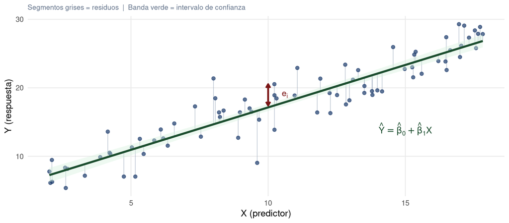

## Mínimos Cuadrados Ordinarios

Criterio MCO

$$\min_{\beta_0,\beta_1} \sum_{i=1}^n (y_i - \beta_0 - \beta_1 x_i)^2$$

Soluciones analíticas:

$$\hat{\beta}_1 = \frac{S_{xy}}{S_{xx}}, \quad \hat{\beta}_0 = \bar{y} - \hat{\beta}_1 \bar{x}$$

Propiedades de MCO

Bajo los supuestos clásicos, los estimadores MCO son **MELI**: Mejores Estimadores Lineales Insesgados (teorema de Gauss-Markov). Tienen la menor varianza entre todos los estimadores lineales insesgados.

**¿Por qué cuadrados?** Para evitar cancelación de errores positivos y negativos, y para que los errores grandes reciban mayor penalización.

## Coeficiente de determinación $R^2$

Definición

$$R^2 = 1 - \frac{SCR}{SCT} = \frac{SCM}{SCT}$$

Proporción de variabilidad de $Y$ explicada por el modelo.

Interpretación

- $R^2 = 1$: ajuste perfecto
- $R^2 = 0$: modelo no explica nada
- $R^2 = 0.75$: el modelo explica el 75% de la variabilidad

Alerta

Un $R^2$ alto no garantiza buen ajuste si los supuestos se violan. Siempre acompañar con diagnóstico de residuos.

En regresión múltiple usar $R^2$ ajustado, que penaliza por el número de predictores.

## Ejemplo en R y Python

- R
- Python

```r
set.seed(2025)
n <- 200
educacion <- runif(n, 4, 18)
ingreso   <- 300000 + 450000 * educacion + rnorm(n, 0, 600000)
datos     <- data.frame(educacion, ingreso)

modelo <- lm(ingreso ~ educacion, data = datos)
# Coeficientes e indicadores clave
coef(modelo)
```

```
(Intercept)   educacion
   434926.4    438549.9
```

```r
cat("R²:", round(summary(modelo)$r.squared, 3),
    " | RSE:", round(summary(modelo)$sigma / 1e3, 1), "miles COP\n")
```

```
R²: 0.908  | RSE: 583 miles COP
```

```python
import numpy as np
import statsmodels.api as sm

np.random.seed(2025)
n = 200
educacion = np.random.uniform(4, 18, n)
ingreso   = 300000 + 450000 * educacion + np.random.normal(0, 600000, n)

X = sm.add_constant(educacion)
res = sm.OLS(ingreso, X).fit()
print(res.params.round(0))
print(f"R²: {res.rsquared:.3f}  |  AIC: {res.aic:.1f}")
```

## Visualización del modelo ajustado

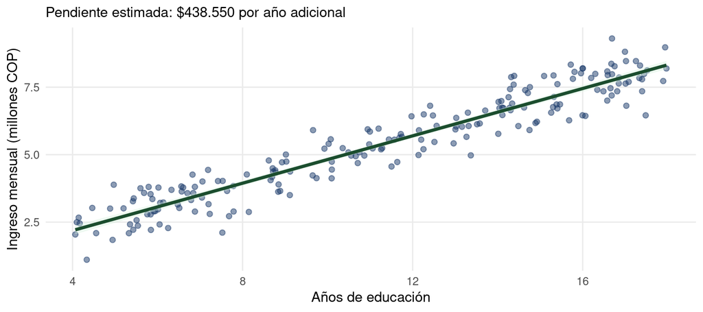

Sección 2 de 8

## Supuestos del Modelo Lineal

El modelo de regresión lineal solo produce inferencias válidas cuando se cumplen ciertos supuestos sobre el término de error. Verificarlos es parte esencial del análisis.

## Supuestos

Linealidad

$E[\varepsilon_i] = 0$. La relación entre $X$ e $Y$ es lineal en los parámetros.

Independencia

Los errores $\varepsilon_i$ son independientes entre sí. Crítico en series de tiempo y datos agrupados.

Normalidad

$\varepsilon_i \sim N(0, \sigma^2)$. Necesaria para intervalos de confianza y pruebas de hipótesis exactas.

Homocedasticidad

$\text{Var}(\varepsilon_i) = \sigma^2$ constante. Si la varianza cambia con $X$, los errores estándar son inválidos.

El supuesto más importante para predicción es la **linealidad**. Para inferencia, la **normalidad**.

## Diagnóstico visual de supuestos

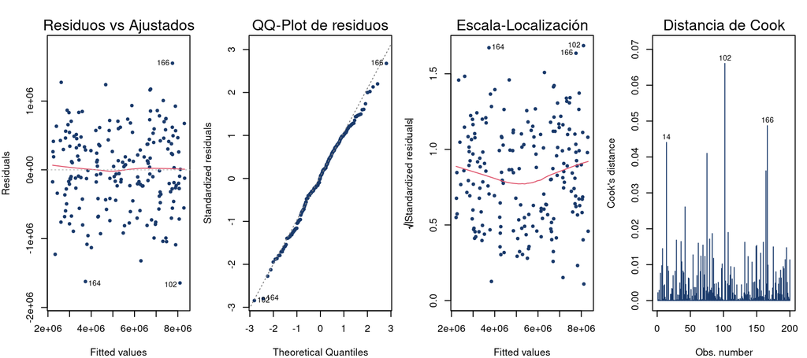

## Lectura de los cuatro gráficos diagnósticos

Linealidad:

Residuos vs Ajustados

Nube aleatoria sin patrón: linealidad se cumple. Un arco indica no linealidad; un embudo indica heterocedasticidad.

Normalidad

QQ-Plot de residuos

Puntos sobre la diagonal: normalidad se cumple. Desviaciones en las colas indican distribución con colas pesadas.

Homocedasticidad

Escala-Localización

Línea horizontal: varianza constante. Una línea creciente o decreciente indica heterocedasticidad.

Observaciones influyentes

Distancia de Cook

Mide cuánto cambia el modelo al eliminar cada punto. $D_i > 1$ merece revisión; $D_i > 4/n$ es señal de alerta.

Sección 3 de 8

## Tipos de Variables en Regresión

La regresión lineal no se limita a un solo tipo de predictor. Variables continuas, discretas y categóricas pueden incluirse, pero cada una requiere un tratamiento diferente.

## ¿Cuándo usar regresión lineal?

Variable respuesta $Y$

Debe ser **cuantitativa continua** (o discreta con muchos valores). Ejemplos: ingreso, temperatura, precio, tiempo de respuesta.  
Si $Y$ es binaria, proporción o conteo, la regresión lineal **no es apropiada**.

| Tipo de $Y$ | Modelo recomendado |
| --- | --- |
| Continua | Regresión lineal |
| Binaria (0/1) | Regresión logística |
| Conteo | Poisson / Neg. binomial |
| Proporción (0,1) | Regresión beta |
| Ordinal | Logística ordinal |

Alerta: error frecuente

Usar regresión lineal con $Y$ binaria puede producir probabilidades fuera de $[0,1]$. Siempre verificar la naturaleza de $Y$ antes de modelar.

## Variables predictoras $X$

Definición: Predictores ($X$)

Los predictores pueden ser de cualquier tipo. Lo que cambia es cómo se incorporan al modelo:

- **Cuantitativo continuo:** se incluye directamente.
- **Cuantitativo discreto:** se incluye directamente.
- **Categórico nominal:** requiere codificación dummy.
- **Categórico ordinal:** puede codificarse numéricamente.

Regla dummy

Una variable con $k$ categorías genera $k-1$ variables indicadoras. La categoría omitida es la **referencia**.

R convierte automáticamente columnas de tipo `factor` en dummies. En Python, usar `pd.get_dummies(drop_first=True)` o la fórmula `C(var)` en `statsmodels`.

## Variables categóricas como predictores

Codificación dummy

Una variable categórica con $k$ niveles se convierte en $k-1$ variables indicadoras (0/1). El nivel excluido actúa como **categoría de referencia**.

Ejemplo: sector laboral (público, privado, independiente)

$$Y = \beta_0 + \beta_1 D_{\text{privado}} + \beta_2 D_{\text{independiente}} + \varepsilon$$

Referencia: sector público. $\hat{\beta}_1$ = diferencia promedio de ingreso entre privado y público.

```r
# Variable categórica como predictor en R
set.seed(1)
sector  <- factor(sample(c("Publico",
                           "Privado",
                           "Independiente"),
                          150,
                          replace=TRUE))

ingreso2 <- 2e6 + 500000*(sector=="Privado") +
            300000*(sector=="Independiente") +
            rnorm(150, 0, 4e5)
mod_cat <- lm(ingreso2 ~ sector)
round(coef(mod_cat) / 1e6, 3)  # en millones
```

```
  (Intercept) sectorPrivado sectorPublico
        2.364         0.042        -0.378
```

R crea automáticamente las variables dummy cuando el predictor es de clase `factor`. La categoría de referencia es la primera en orden alfabético: “Independiente” en este caso.

Sección 4 de 8

## Regresión Lineal Múltiple

Cuando la respuesta depende de varios factores simultáneamente, la regresión múltiple permite aislar el efecto de cada predictor, controlando por los demás.

## Regresión lineal múltiple

Modelo general

$$Y_i = \beta_0 + \beta_1 X_{i1} + \cdots + \beta_p X_{ip} + \varepsilon_i$$

Forma matricial: $\mathbf{Y} = \mathbf{X}\boldsymbol{\beta} + \boldsymbol{\varepsilon}$, solución MCO: $\hat{\boldsymbol{\beta}} = (\mathbf{X}^\top \mathbf{X})^{-1}\mathbf{X}^\top \mathbf{Y}$.

**$\hat{\beta}_j$**: efecto promedio de $X_j$ sobre $Y$ *manteniendo constantes todos los demás predictores*.

Ejemplo: Ingreso en Colombia

$$\widehat{\text{Ingreso}} = \beta_0 + \beta_1\,\text{Edu} + \beta_2\,\text{Exp} + \beta_3\,\text{Género}$$

$\hat{\beta}_1 = 380.000$: un año más de educación aumenta el ingreso en $\$380.000$ promedio, **controlando experiencia y género**.

La diferencia clave con la regresión simple: los coeficientes son **efectos parciales o condicionales**, no marginales. Cambian cuando se agregan o quitan predictores.

## Multicolinealidad

Problema

Ocurre cuando dos o más predictores están **altamente correlacionados** entre sí. El modelo no puede distinguir el efecto individual de cada uno.

**Consecuencias:**

- Coeficientes inestables (cambian mucho con pequeñas variaciones en los datos)
- Errores estándar inflados
- Coeficientes con signo contrario al esperado

Factor de Inflación de Varianza (VIF)

$$VIF_j = \frac{1}{1 - R^2_j}$$
$R^2_j$: coeficiente al regresar $X_j$ contra los demás predictores. Regla: $VIF > 5$ es alerta; $VIF > 10$ indica multicolinealidad severa.

```r
library(car)
set.seed(7)
edu  <- runif(100, 5, 18)
exp_ <- 40 - edu + rnorm(100, 0, 3)   # correlacionadas con educación
ing  <- 2e6 + 3e5*edu + 8e4*exp_ + rnorm(100, 0, 5e5)
mod_mult <- lm(ing ~ edu + exp_)
round(vif(mod_mult), 2)
```

```
 edu exp_
3.08 3.08
```

## Ejemplo: Regresión múltiple en R y Python

- R
- Python

```r
set.seed(42)
n   <- 300
edu <- runif(n, 4, 18)
exp2 <- runif(n, 0, 30)
gen <- rbinom(n, 1, 0.5)
ing3 <- 500000 + 400000*edu + 50000*exp2 - 200000*gen + rnorm(n, 0, 8e5)
datos3 <- data.frame(ingreso = ing3, educacion = edu,
                     experiencia = exp2, genero = factor(gen))
mod3 <- lm(ingreso ~ educacion + experiencia + genero, data = datos3)
round(coef(mod3) / 1e3, 1)  # en miles de pesos
```

```
(Intercept)   educacion experiencia     genero1
      233.9       416.9        49.7      -138.7
```

```python
import pandas as pd
import numpy as np
import statsmodels.formula.api as smf

np.random.seed(42)
n = 300
df = pd.DataFrame({
    "educacion"   : np.random.uniform(4, 18, n),
    "experiencia" : np.random.uniform(0, 30, n),
    "genero"      : np.random.binomial(1, 0.5, n)
})
df["ingreso"] = (500000 + 400000*df.educacion + 50000*df.experiencia
                 - 200000*df.genero + np.random.normal(0, 8e5, n))

modelo = smf.ols("ingreso ~ educacion + experiencia + C(genero)", data=df).fit()
print(modelo.params / 1000)  # en miles de pesos
```

## ¿Qué hacer cuando no se cumplen los supuestos?

No linealidad

Agregar términos cuadráticos (`X²`) o de interacción, o aplicar transformaciones: `log(Y)`, `√Y`, `1/Y`.

Heterocedasticidad

Usar regresión con errores robustos (HC), mínimos cuadrados ponderados (WLS), o transformar la variable respuesta.

Autocorrelación

Agregar rezagos de la variable respuesta, usar mínimos cuadrados generalizados (GLS) o modelos de series de tiempo.

No normalidad de residuos

Con muestras grandes no es crítico (TLC). En muestras pequeñas: transformar `Y` o usar regresión robusta (Huber, cuantílica).

Multicolinealidad

Eliminar variables redundantes, combinarlas en índices o usar regularización: **Ridge** (L2) o **Lasso** (L1).

Regla de oro

Diagnosticar **antes** de interpretar. Un modelo con supuestos violados produce coeficientes e intervalos de confianza no confiables.

Cuantifica relaciones

A diferencia de la visualización o las tablas de contingencia, la regresión asigna un **valor numérico al efecto** de cada variable.

Permite predicción

Con el modelo ajustado se puede estimar el valor de $Y$ para observaciones nuevas. Es la base del aprendizaje supervisado.

Es interpretable

Los coeficientes tienen significado directo en la escala de los datos. Un modelo que se puede explicar vale más que uno de caja negra con mayor precisión.

Es la línea base

En cualquier proyecto de minería, la regresión lineal o logística es el primer modelo que se ajusta. Si un modelo complejo no supera a la regresión, la complejidad adicional no se justifica.

Usos concretos en minería de datos

- Predecir precios, ventas o demanda.
- Estimar probabilidad de churn, fraude o mora.
- Cuantificar el efecto de una intervención.
- Seleccionar variables relevantes para modelos posteriores.

Sección 5 de 8

## Regresión Logística

Cuando la variable respuesta es binaria (sí/no, éxito/fracaso, enfermo/sano), la regresión logística modela la probabilidad del evento a través de la función sigmoide.

## ¿por qué no usar regresión lineal?

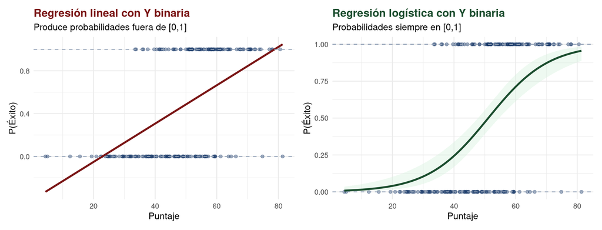

## El modelo logístico: función y logit

Función sigmoide

Modela la probabilidad de que $Y=1$ dado $X$:

$$P(Y=1 \mid X) = \frac{e^{\eta}}{1 + e^{\eta}} = \sigma(\eta)$$

$\sigma(\eta)$ mapea $\mathbb{R} \to (0,1)$: las probabilidades siempre son válidas.

Logit lineal

Equivalentemente, el logit de la probabilidad es lineal en $X$:

$$\ln\!\left(\frac{p}{1-p}\right) = \beta_0 + \beta_1 X$$

$\frac{p}{1-p}$: razón de momios (odds). El logit es su logaritmo natural.

## El modelo logístico: estimación y supuestos

Estimación por máxima verosimilitud

Los parámetros se estiman maximizando la log-verosimilitud binomial. No existe solución analítica cerrada; se usan algoritmos iterativos (IRLS). En R: `glm(…, family = binomial)`.

**Supuestos:** linealidad del logit con $X$, independencia de observaciones, ausencia de multicolinealidad severa. No se asume normalidad de los errores.

Alerta: separación perfecta

Si un predictor separa completamente las clases, los coeficientes divergen hacia $\pm\infty$. Señal: coeficientes muy grandes con errores estándar enormes.

## Interpretación de coeficientes

En escala logit

$\hat{\beta}_1$

Cambio en el log-odds por una unidad adicional de $X$. Dirección del efecto, pero magnitud poco intuitiva.

Odds Ratio (OR)

$OR = e^{\hat{\beta}_1}$

Una unidad más de $X$ multiplica los odds del evento por $e^{\hat{\beta}_1}$. Es la interpretación más usada en epidemiología y ciencias sociales.

**$OR > 1$:** aumenta el riesgo. **$OR < 1$:** lo reduce.

Efecto marginal

$\frac{\partial P}{\partial X} = \hat{\beta}_1 \cdot p(1-p)$

Cambio en la *probabilidad* por unidad de $X$, evaluado en la probabilidad media. Varía según el punto de evaluación.

## Interpretación OR

Ejemplo: Riesgo de deserción universitaria

Si $\hat{\beta}_1 = -0.15$ para el puntaje Saber 11, entonces $OR = e^{-0.15} \approx 0.86$: por cada punto adicional en Saber 11, los odds de desertar se **reducen en un 14%**, controlando por los demás factores del modelo.

**Cuando $OR > 1$:** el predictor aumenta los odds del evento. Un $OR = 2$ significa que los odds se duplican por cada unidad adicional de $X$.

**Cuando $OR < 1$:** el predictor reduce los odds. Un $OR = 0.5$ significa que los odds se reducen a la mitad por cada unidad adicional de $X$.

## Regresión logística en R y Python

- R
- Python

```r
set.seed(2025)
n <- 400
puntaje  <- rnorm(n, 50, 12)
estrato  <- sample(1:4, n, replace = TRUE)
desercion <- rbinom(n, 1, plogis(3 - 0.08*puntaje - 0.3*estrato))
df_des   <- data.frame(desercion, puntaje, estrato)

mod_log <- glm(desercion ~ puntaje + estrato,
               data = df_des, family = binomial)
# Odds ratios con intervalos de confianza
round(exp(cbind(OR = coef(mod_log), confint(mod_log))), 3)
```

```
                OR 2.5 % 97.5 %
(Intercept) 16.820 5.079 59.246
puntaje      0.935 0.912  0.957
estrato      0.659 0.515  0.836
```

```python
import numpy as np
import pandas as pd
from sklearn.linear_model import LogisticRegression
from sklearn.preprocessing import StandardScaler

np.random.seed(2025)
n = 400
df = pd.DataFrame({
    "puntaje" : np.random.normal(50, 12, n),
    "estrato" : np.random.randint(1, 5, n)
})
p = 1 / (1 + np.exp(-(3 - 0.08*df.puntaje - 0.3*df.estrato)))
df["desercion"] = np.random.binomial(1, p)

X = df[["puntaje","estrato"]]
y = df["desercion"]

modelo = LogisticRegression()
modelo.fit(X, y)
print("Coeficientes:", modelo.coef_)
print("Accuracy:", modelo.score(X, y).round(3))
```

## Evaluación del modelo logístico

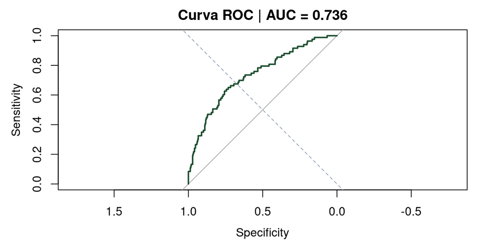

```r
# Curva ROC
library(pROC)
prob_pred <- predict(mod_log, type = "response")
roc_obj   <- roc(df_des$desercion, prob_pred, quiet = TRUE)
plot(roc_obj, col = "#1b4d2e", lwd = 2,
     main = paste("Curva ROC | AUC =", round(auc(roc_obj), 3)))
abline(a = 0, b = 1, lty = 2, col = "#94a3b8")
```

Definición: AUC-ROC

El AUC (Area Under the Curve) mide la capacidad del modelo para distinguir entre las dos clases. Va de 0.5 (aleatorio) a 1 (perfecto).

Otras métricas

| Accuracy | Proporción de clasificaciones correctas |
| --- | --- |
| Sensibilidad | Tasa de verdaderos positivos |
| Especificidad | Tasa de verdaderos negativos |
| AUC | Discriminación global del modelo |

Alerta: accuracy engañoso

En clases desbalanceadas, un modelo que siempre predice la clase mayoritaria puede tener accuracy alto. Preferir AUC, F1 o la matriz de confusión completa.

## Lineal simple vs múltiple vs logística

| Característica | Lineal Simple | Lineal Múltiple | Logística |
| --- | --- | --- | --- |
| Variable $Y$ | Continua | Continua | Binaria (0/1) |
| Predictores | 1 | $p \geq 2$ | 1 o más |
| Estimación | MCO | MCO | Máx. verosimilitud |
| Interpretación $\hat{\beta}$ | Cambio en $Y$ | Cambio parcial en $Y$ | Cambio en log-odds |
| Métrica principal | $R^2$, RMSE | $R^2_{adj}$, RMSE | AUC, Devianza |
| R | lm(y~x) | lm(y~x1+x2) | glm(…, binomial) |

## Errores comunes en modelos de regresión

Errores frecuentes

- **Interpretar causalidad:** la regresión mide asociación, no causa.
- **Ignorar supuestos:** un $R^2$ alto no compensa residuos con patrón.
- **No revisar multicolinealidad:** VIF elevado produce coeficientes con signo inesperado.
- **Regresión lineal con $Y$ binaria:** produce probabilidades fuera de $[0,1]$.
- **Confundir logit con probabilidad:** siempre exponenciar para obtener OR.

Buena práctica antes de publicar

1. Revisar los cuatro gráficos diagnósticos.
2. Calcular VIF en todo modelo con más de un predictor.
3. Validar el modelo fuera de muestra (train/test o CV).
4. Reportar coeficientes con IC al 95%, no solo el valor puntual.

Sección 6 de 8

## Modelos Lineales Generalizados

Los MLG extienden la regresión lineal a variables respuesta no gaussianas: conteos, proporciones y más, mediante una función de enlace.

## ¿Qué es un Modelo Lineal Generalizado?

Idea central

La regresión lineal asume que $Y$ es continuo y los errores son normales. Pero en la realidad muchas variables respuesta son **binarias, conteos o proporciones**.

Los **Modelos Lineales Generalizados (MLG)** extienden la regresión lineal para responder a esa variedad, manteniendo la misma intuición de “combinación lineal de predictores.”

**Analogía:** la regresión lineal es un caso particular del MLG, igual que el cuadrado es un caso particular del rectángulo.

Tres componentes del MLG

1. **Componente aleatoria:** distribución de $Y$ (Normal, Binomial, Poisson…).
2. **Componente sistemática:** predictor lineal $\eta = \beta_0 + \beta_1 X_1 + \cdots$.
3. **Función de enlace:** $g(\mu) = \eta$, conecta la media de $Y$ con el predictor lineal.

Lo que cambia entre modelos es la **distribución de $Y$** y la **función de enlace**. El predictor lineal $\eta$ siempre es el mismo.

## Función de enlace: la clave del MLG

La función de enlace $g(\mu)$ transforma la media de $Y$ para que pueda modelarse como combinación lineal. Cada tipo de respuesta tiene un enlace natural.

| Tipo de $Y$ | Distribución | Enlace $g(\mu)$ | Modelo resultante |
| --- | --- | --- | --- |
| Continua | Normal | $\mu$ (identidad) | Regresión lineal |
| Binaria (0/1) | Binomial | $\ln\!\left(\frac{\mu}{1-\mu}\right)$ (logit) | Regresión logística |
| Conteo ($0,1,2,...$) | Poisson | $\ln(\mu)$ (log) | Regresión de Poisson |
| Binaria (0/1) | Binomial | $\Phi^{-1}(\mu)$ (probit) | Regresión probit |

En R, todos estos modelos se ajustan con `glm(y ~ x, family = …)`. Cambia solo el argumento `family`: `gaussian`, `binomial`, `poisson`.

## Regresión logística como caso del MLG

MLG con enlace logit

Distribución de $Y$: **Binomial**. La media es $\mu = P(Y=1)$, que debe estar en $(0,1)$.

$$g(\mu) = \ln\!\left(\frac{\mu}{1-\mu}\right) = \eta = \beta_0 + \beta_1 X$$

Despejando $\mu$: $\mu = \sigma(\eta) = \frac{e^\eta}{1+e^\eta}$, que es la función sigmoide.

No confundir el enlace con la distribución

El enlace logit también puede usarse con distribución Binomial de varios ensayos. El enlace probit da resultados muy similares al logit pero supone errores con distribución normal estándar en vez de logística.

Ejemplo: glm() en R

`glm(y ~ x1 + x2, family = binomial(link = “logit”))`  
Cambiando `family` se obtiene el modelo apropiado para cada tipo de respuesta, sin cambiar nada más en el flujo de trabajo.

**¿Por qué el enlace logit es natural para datos binarios?** Porque transforma probabilidades del intervalo $(0,1)$ a toda la recta real $(-\infty, +\infty)$, donde el predictor lineal puede tomar cualquier valor.

Sección 7 de 8

## ¿Hay más sobre regresión?

Existen familias de modelos especializados para situaciones que la regresión clásica no cubre bien: datos agrupados, distribuciones asimétricas, tiempos hasta eventos y más.

## Otros modelos de regresión: panorama general

Regresión cuantílica

Modela **cuantiles** de Y (mediana, percentil 90…) en lugar de la media. Robusta a valores atípicos.

*Paquete: `quantreg` (R), `statsmodels` (Python)*

Modelos mixtos (efectos aleatorios)

Datos **agrupados o longitudinales** (estudiantes en colegios, pacientes en hospitales). Captura variabilidad entre grupos.

*Paquete: `lme4` (R), `statsmodels` (Python)*

Regresión robusta

Usa funciones de pérdida menos sensibles a valores atípicos (estimadores M de Huber). Alternativa cuando los residuos no son normales.

*Paquete: `MASS::rlm` (R), `statsmodels` (Python)*

GAMs y regresión spline

Modelos **aditivos generalizados**: cada predictor entra con una función suave. Flexibles sin ser una caja negra.

*Paquete: `mgcv` (R), `pygam` (Python)*

Modelos de supervivencia (Cox)

Modela el **tiempo hasta un evento** (falla, muerte, abandono). Maneja datos censurados correctamente.

*Paquete: `survival` (R), `lifelines` (Python)*

Regresión bayesiana

Incorpora **conocimiento previo** (priors) y produce distribuciones posteriores de los coeficientes, no solo estimaciones puntuales.

*Paquete: `brms` (R), `PyMC` (Python)*

Sección 8 de 8

## Series de Tiempo

Cuando las observaciones están ordenadas en el tiempo y no son independientes entre sí, los modelos clásicos de regresión dejan de ser válidos. Las series de tiempo tienen su propia familia de modelos.

## ¿Qué es una serie de tiempo?

Definición

Una **serie de tiempo** es una secuencia de observaciones $\{Y_t\}$ registradas en instantes sucesivos $t = 1, 2, \ldots, T$, donde el orden importa y las observaciones cercanas en el tiempo tienden a parecerse.

**Diferencia clave con regresión:** en regresión asumimos observaciones independientes. En series de tiempo, $Y_t$ depende de $Y_{t-1}, Y_{t-2}, \ldots$

Ejemplo: contexto colombiano

- Precio del dólar (TRM) diario.
- Casos de dengue por semana epidemiológica.
- Exportaciones de café por trimestre.
- Temperatura en Bogotá por mes.

En minería de datos, las series de tiempo aparecen cuando los datos vienen de **registros transaccionales, sensores o monitoreo continuo**. Ignorar la dependencia temporal produce modelos incorrectos.

## Componentes de una serie de tiempo

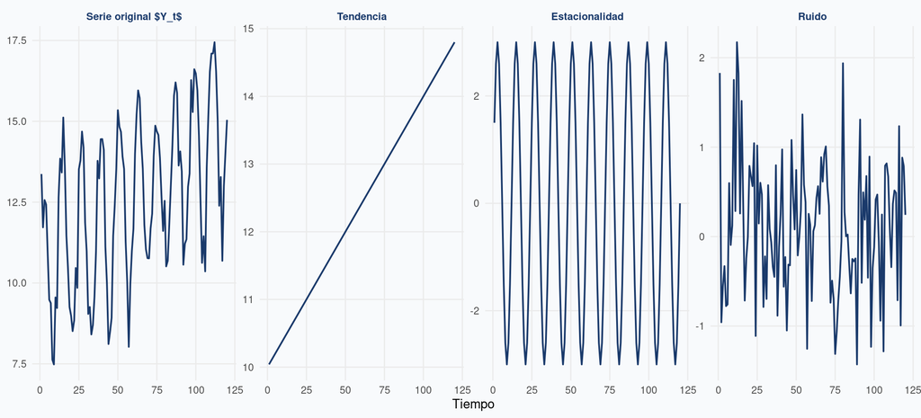

Definición: Descomposición $Y_t = T_t + S_t + \varepsilon_t$

**$T_t$** Tendencia: dirección de largo plazo (crecimiento, decrecimiento). **$S_t$** Estacionalidad: patrón que se repite con periodicidad fija. **$\varepsilon_t$** Ruido: variación aleatoria no explicada por los otros dos.

## Supuestos básicos: estacionariedad

Definición:

Una serie es **estacionaria** si sus propiedades estadísticas no cambian con el tiempo:

- Media constante: $E[Y_t] = \mu$ para todo $t$.
- Varianza constante: $\text{Var}(Y_t) = \sigma^2$ para todo $t$.
- Covarianza que depende solo del rezago: $\text{Cov}(Y_t, Y_{t-k}) = \gamma_k$.

La mayoría de series reales no son estacionarias

Series con tendencia o estacionalidad no son estacionarias. Antes de ajustar modelos ARMA, hay que transformar: diferenciar, aplicar logaritmo o eliminar la tendencia.

**Prueba de Dickey-Fuller aumentada (ADF):** contrasta $H_0$: la serie tiene raíz unitaria (no es estacionaria). Si $p < 0.05$, se rechaza $H_0$ y la serie puede considerarse estacionaria.

## Modelos clásicos: AR, MA y ARMA

AR($p$): Autoregresivo

$$Y_t = \phi_1 Y_{t-1} + \cdots + \phi_p Y_{t-p} + \varepsilon_t$$

$Y_t$ depende linealmente de sus $p$ valores pasados. Captura inercia o persistencia.

Ejemplo: el precio de hoy depende de los últimos 3 días.

MA($q$): Media Móvil

$$Y_t = \varepsilon_t + \theta_1 \varepsilon_{t-1} + \cdots + \theta_q \varepsilon_{t-q}$$

$Y_t$ depende de los $q$ errores pasados. Captura shocks o perturbaciones recientes.

Ejemplo: un evento climático afecta las ventas durante 2 semanas.

ARMA($p$,$q$)

$$Y_t = \sum_{i=1}^p \phi_i Y_{t-i} + \varepsilon_t + \sum_{j=1}^q \theta_j \varepsilon_{t-j}$$

Combina AR y MA. Aplica solo a series estacionarias. El caso más usado en la práctica.

En R: `arima(y, order=c(p,0,q))`

## ARIMA: para series no estacionarias

ARIMA($p$, $d$, $q$)

Extiende ARMA aplicando **$d$ diferenciaciones** para lograr estacionariedad antes de ajustar el modelo.

**$p$:** orden autoregresivo (AR)  
**$d$:** número de diferenciaciones (I de Integrated)  
**$q$:** orden de media móvil (MA)

Si $d=0$: ARMA. Si $p=0,d=1,q=0$: caminata aleatoria. Si $p=0,d=1,q=1$: modelo ETS simple.

Ejemplo en R y Python

- R
- Python

```r
library(forecast)
# Identificación automática del mejor ARIMA
modelo <- auto.arima(serie_temporal)
summary(modelo)
forecast(modelo, h = 12)  # 12 pasos adelante
```

```python
from statsmodels.tsa.arima.model import ARIMA

modelo = ARIMA(serie, order=(1, 1, 1))
resultado = modelo.fit()
print(resultado.summary())
```

`auto.arima()` en R selecciona automáticamente $p$, $d$ y $q$ usando criterios de información (AIC). Es el punto de partida recomendado en la práctica.

## Resumen: ¿qué modelo usar?

| Situación | Modelo | Supuesto clave | R |
| --- | --- | --- | --- |
| $Y$ continua, obs. independientes | Regresión lineal | LINE | lm() |
| $Y$ binaria | Regresión logística | Linealidad del logit | glm(…,binomial) |
| $Y$ conteo | Poisson / Neg. Bin. | Equidispersión | glm(…,poisson) |
| Serie temporal estacionaria | ARMA($p$,$q$) | Estacionariedad | arima() |
| Serie temporal con tendencia | ARIMA($p$,$d$,$q$) | Estacion. tras $d$ dif. | auto.arima() |

Antes de elegir el modelo, siempre graficar la serie, revisar la función de autocorrelación (ACF) y la función de autocorrelación parcial (PACF). Estas gráficas guían la elección de $p$ y $q$.

## La fase del KDD que genera conocimiento

Esta clase ocupa la fase central del KDD donde los patrones se convierten en modelos formales que explican y predicen.

Selección

Elegir datos relevantes del repositorio

→

Preprocesamiento

Limpiar, imputar, transformar

→

Transformación

EDA, reducción de dimensión, codificación

→

Minería de datos

Regresión lineal, logística, MLG, series de tiempo

Aquí se extrae el patrón cuantificado

→

Evaluación

Validar, interpretar y comunicar resultados

Es la única fase que **produce conocimiento accionable**: un coeficiente que cuantifica un efecto, una probabilidad que clasifica un riesgo, un pronóstico que anticipa una demanda. Las demás fases preparan o comunican; esta fase decide.

Los modelos son la **línea base** en cualquier proyecto de minería. Antes de aplicar redes neuronales o bosques aleatorios, el analista debe “dominar” regresión y series de tiempo: son interpretables, auditables y suficientes en la mayoría de problemas reales.

## Ejercicios de práctica

```r
set.seed(42)
n <- 120
ventas <- data.frame(
  mes        = rep(1:12, times = 10),
  publicidad = round(runif(n, min = 2.0, max = 4.5), 1),
  precio     = round(runif(n, min = 13.0, max = 15.5), 1),
  region     = sample(c("Norte", "Sur", "Este", "Oeste"), n, replace = TRUE),
  promo      = sample(c(0L, 1L), n, replace = TRUE)
)
ventas$ventas <- round(
  100 + 18 * ventas$publicidad - 5 * ventas$precio +
    rnorm(n, mean = 0, sd = 8)
)
```

## Ejercicios de práctica (continuación)

Ejercicio 1: Regresión simple

Ajuste un modelo de regresión lineal simple que explique las **ventas** a partir del **gasto en publicidad**. Interprete el coeficiente de publicidad y el R². ¿El gasto en publicidad explica bien las ventas?

Ejercicio 2: Regresión múltiple

Ajuste un modelo de regresión lineal múltiple con **publicidad** y **precio** como predictores. Compare el R² ajustado con el del ejercicio anterior. ¿Cuál variable aporta más a explicar las ventas?

## Ejercicios de práctica (continuación)

Ejercicio 3: Variable categórica

Incluya la variable **region** como predictor en el modelo múltiple. Codifíquela correctamente como variable dummy. ¿Existe diferencia significativa en ventas entre regiones? Interprete los coeficientes.

Ejercicio 4: Regresión logística

Use la variable **promo** (0 = sin promoción, 1 = con promoción) como variable dependiente. Ajuste un modelo logístico con **publicidad** y **precio** como predictores. Reporte los odds ratios e interprete el efecto del precio sobre la probabilidad de aplicar una promoción.

Ejercicio 5: Diagnóstico y comunicación

Para el modelo múltiple del ejercicio 2, genere los **gráficos de diagnóstico** (residuales vs. ajustados, Q-Q de residuales, escala-localización). Identifique si se cumplen los supuestos de linealidad, homocedasticidad y normalidad. Redacte una conclusión de dos párrafos como si fuera para un informe de negocio.